# Linear Mixed Models

Fernando Miguez

6/3/2019

## Chapter 1: Linear Mixed Models

Include here an introduction to linear mixed models (https://stats.idre.ucla.edu/other/mult-pkg/introduction-to-linear-mixed-models/).

Wiki (https://en.wikipedia.org/wiki/Mixed_model).

### Background

Some useful background for the following topic is: (doi: 10.2134/agronj2019.02.0135).

## Example: soybean row spacing meta-analysis

This first example is for soybean row spacing. The question is: is there a difference between growing soybean using rows 15 inches apart vs. 30 in apart? The planting density is assumed to be the same so only the configuration of the planting scheme was changed. The experimental design is that of paired strips, but it is organized in different trials located in different farms. Each farm/field/trial has unique soils, management history and experiences their own weather conditions. They are all located in Iowa and each season will exert similar effects (e.g. dry vs. wet). It is common to analyze the data as the response ration, or the yield of the treatment over the yield of the control. Taking the log is common practice.

$$RR = \frac{Yield_T}{Yield_C}$$

$$lrr = \log(RR)$$

```r
soy <- read.csv("./ch1/srs.csv")[,c(1,4,7,9)]
## Select only a subset of data
soy$lrr <- log(soy$TRT1_Yld/soy$TRT2_Yld)
soy.o <- soy[order(soy$lrr),]
soy.o$id <- 1:nrow(soy.o)
```

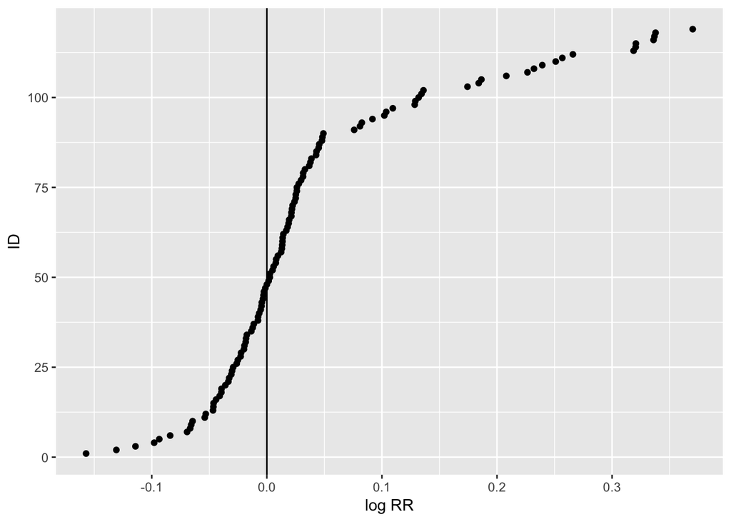

```r
round(dim(subset(soy.o, lrr > 0))[1]/nrow(soy.o),2)
```

```
## [1] 0.6
```

There is a clear break which suggests that some of these trials are quite different from the rest. Which variable explains these differences? Almost all of the high values were from year 2014. In addition, we should also investigate how do the observations group with respect to studies.

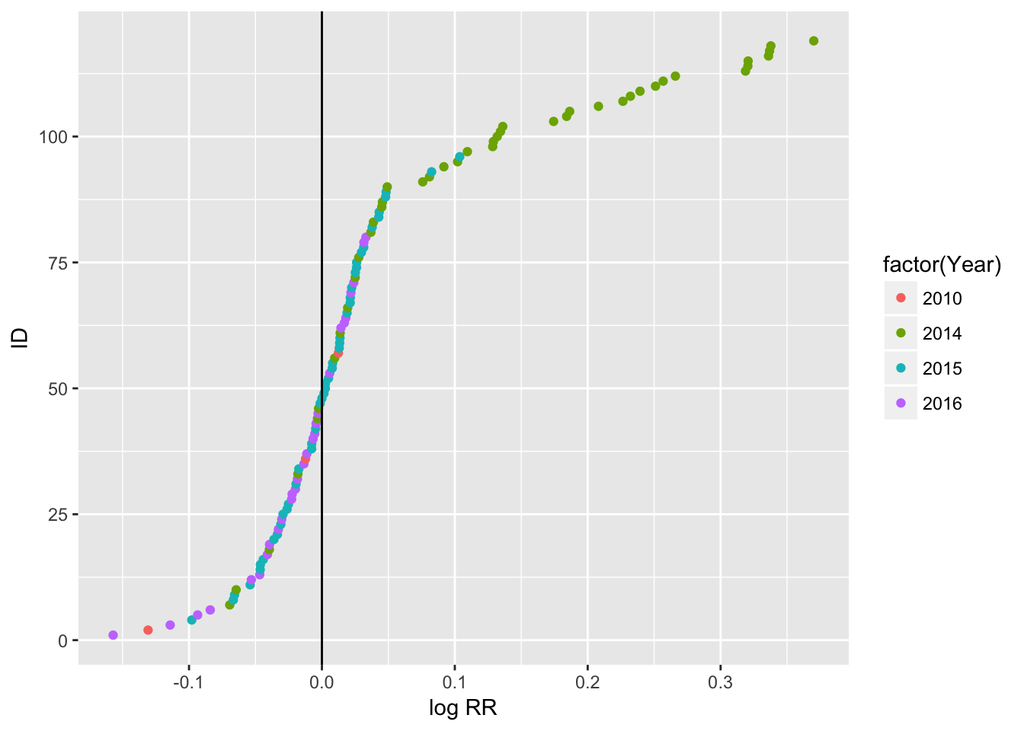

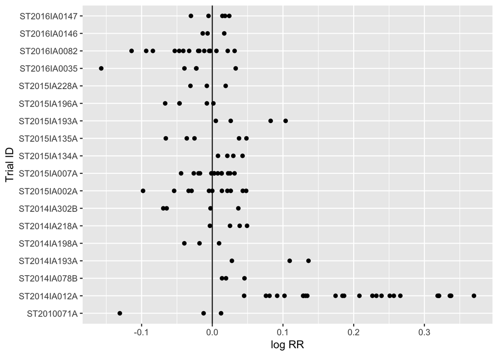

Almost all of the observations which have a large response are from a single study. It is not uncommon to throw this out and call it an ‘outlier’, but we don’t have a reason for doing this at the moment. What if it truly represents a situation that can occurr again? We should consider it as part of the decision making process.

## Confidence intervals for each individual study

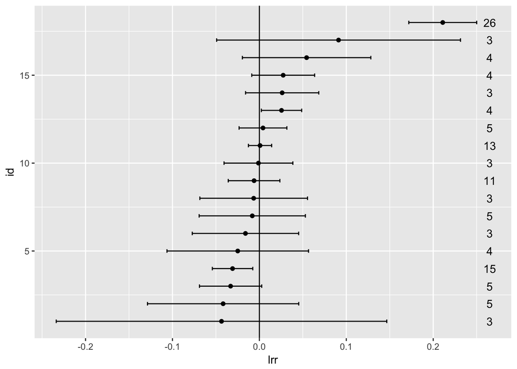

```r
cif <- function(x, alpha=0.05){
  n.x <- length(x)
  se.x <- sd(x)/sqrt(n.x)
  m.x <- mean(x)
  qv <- qt(1-alpha/2, n.x-1)
  lci <- m.x -  qv * se.x
  uci <- m.x + qv * se.x
  ans <- c(lci, m.x, uci)
  names(ans) <- c("lci", "m", "uci")
  return(ans)
}
soy.a <- aggregate(lrr ~ Trial_ID, data = soy.o, FUN = cif)
soy.a2 <- data.frame(trial = soy.a$Trial_ID, soy.a$lrr)
## Weirdest hack ever
soy.a2.o <- soy.a2[order(soy.a2$m),]
soy.a2.o$id <- 1:nrow(soy.a2.o)

soy.tn <- aggregate(lrr ~ Trial_ID, data = soy.o, FUN = length)
names(soy.tn) <- c("trial","n")

soy.a3 <- merge(soy.a2.o, soy.tn)

ggplot(data = soy.a3, aes(x = m, y = id)) +
  geom_point() + xlab("lrr") +
  geom_errorbarh(aes(xmin = lci, xmax = uci), height = 0.2) +
  geom_vline(xintercept = 0) +
  geom_text(aes(x = 0.265, y = id), label = as.character(soy.a3$n))
```

The variability in the confidence intervals is a reflection of both the underlying data and the sample size within each trial. Trials with a smaller sample size tend to have wider confidence intervals.

```r
## Number of trials with a positive response (ci does not include zero)
## - proportion
sstgz <- subset(soy.a3, lci > 0)
cat("Trials sig. > 0:",round(nrow(sstgz)/nrow(soy.a3),2),"\n")
```

```
## Trials sig. > 0: 0.11
```

```r
sstlz <- subset(soy.a3, uci < 0)
cat("Trials sig. < 0:", round(nrow(sstlz)/nrow(soy.a3),2),"\n")
```

```
## Trials sig. < 0: 0.06
```

```r
cat("Trials incl. 0:",round(1 - (nrow(sstgz) + nrow(sstlz))/nrow(soy.a3),2),"\n")
```

```
## Trials incl. 0: 0.83
```

Now only 11% of the trials had a significant positive response, about 6% had a significant negative response and the rest, 83%, had a response for which the confidence interval included zero. This is much less promising than the 60% we observed previously, but now we are counting the number of trials which had a positive reponse instead of the number of observations. It is somewhat ironic that the trial with the highest number of reps (the one with the highest precision) is the one that deviates the most with the observed response in the rest of the trials. This trial experienced hail, which is likely involed in the observed response. One possible explanation for the one trial which had a negative response could be due to higher moisture in the canopy (in narrow rows) which leads to higher disease pressure, particularly white mold.

## Linear Model

The disadvantage of the previous analysis is that we are not analyzing the data together. If we want to make a statement about the overall performance of the management practice, combining the trials is necessary. In the following steps we will gradually increase the complexity of the analysis. The first model (lm0) does not include trial, it analyzes the data ignaring its structure.

```r
## Fitting a first model without trial, just the intercept
soy.lm0 <- lm(lrr ~ 1, data = soy.o)
## Parameter confidence interval
pp.lm0 <- predict(soy.lm0, newdata = data.frame(lrr = mean(soy.o$lrr)),
                  interval = "confidence")
## Individual observation confidence interval
ppp.lm0 <- predict(soy.lm0, newdata = data.frame(lrr = mean(soy.o$lrr)),
                  interval = "prediction")
```

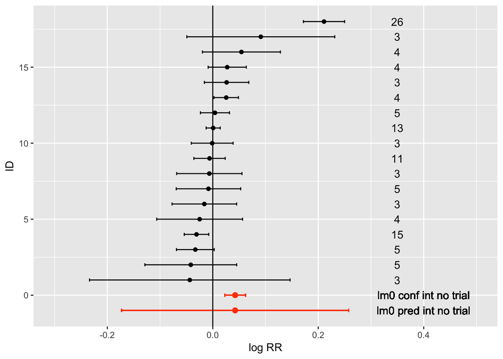

A second step would be to include ‘trial’ in the model, but still in the context of a linear model. This model tests whether there is an effect of ‘trial’ (in this case it is significant); at least one trial has an effect which is different from the rest.

```r
## Fitting a first model without trial
## options(constrasts = rep(c("contr.treatment"),2))
## Need to look into defining other contrasts
soy.lm1 <- lm(lrr ~ Trial_ID, data = soy.o)
pp.lm1 <- predict(soy.lm1,
                  newdata = data.frame(Trial_ID = unique(soy.o$Trial_ID)),
                  interval = "confidence")
pp.lm1d <- data.frame(trial = unique(soy.o$Trial_ID), pp.lm1)
pp.lm1d2 <- merge(soy.a3, pp.lm1d)
## prediciton interval for the trial which is closer to the mean
pmt <- which.min(abs(pp.lm1d$fit - coef(soy.lm0)))
## The previous is potentially dangerous, because the actual mean might
## be far away from any trial in particular
ppp.lm1 <- predict(soy.lm1,
              newdata = data.frame(Trial_ID = unique(soy.o$Trial_ID)[pmt]),
                                          interval = "prediction")
ppp.lm1 <- as.data.frame(ppp.lm1)
```

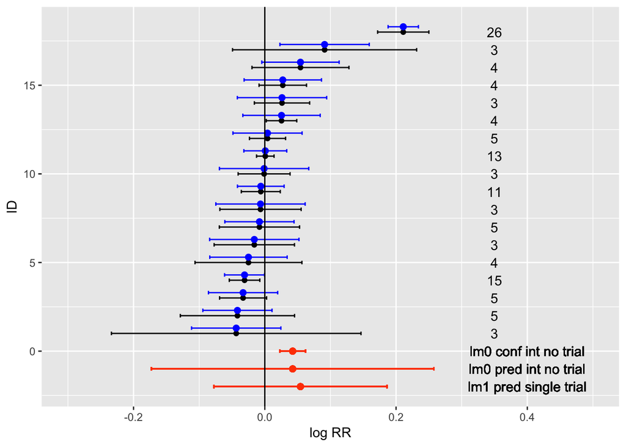

## Linear Mixed Models

We have more or less exhausted what we can do using linear models for this example (not really). Now we move on to mixed models and we consider ‘trials’ as ‘random’. This means that we are less focus on what has happened on each individual trial and we think of trials as being ‘sampled’ from a larger population. When considered factors as fixed we assume that we can replicate that level, but here each trial is an ocurrence which we cannot easily replicate.

```r
soy.lme <- lmer(lrr ~ 1 + (1|Trial_ID), data = soy.o)
round(exp(fixef(soy.lme)),3)
```

```
## (Intercept)
##       1.014
```

```r
round(exp(confint(soy.lme, quiet = T))[3,],3)
```

```
##  2.5 % 97.5 %
##  0.983  1.046
```

```r
##exp(confint(soy.lme))
##exp(confint(soy.lme, method = "boot"))
##For these type of models there are different methods for
##computing confidence intervals ("profile","Wald","boot").

## Confidence intervals and predictions
ci.lme <- confint(soy.lme, quiet = T)[3,]
pp.lme <- c(fixef(soy.lme),ci.lme[1],ci.lme[2])
```

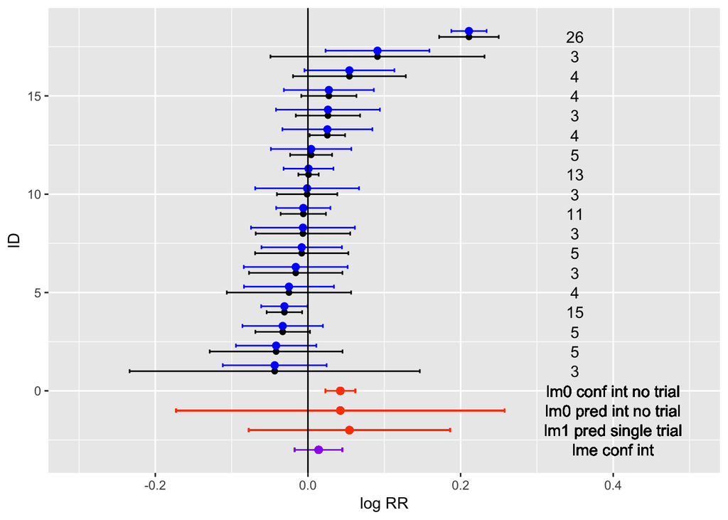

Following Higgins et al. (2009) we can calculate the prediction interval

$$\hat{\mu} \pm t^{\alpha}_{k-2} \sqrt{\hat{\tau}^2 + SE(\hat{\mu})^2}$$
$$\hat{\mu} = \text{estimated mean}$$
$$\hat{\tau} = \text{between studies std. deviation}$$
$$SE(\hat{\mu}) = \text{standard error for the intercept}$$

```r
n.k <- length(soy.a3$trial)
t.val <- qt(1 - 0.05/2, n.k-2)
tau.sqrd <- VarCorr(soy.lme)$Trial_ID[1]
se.mu <- unlist(summary(soy.lme))$coefficients2
se.muh <- sqrt(tau.sqrd + se.mu^2)
pdi <- t.val * se.muh
mu.lci <- fixef(soy.lme) - pdi
mu.uci <- fixef(soy.lme) + pdi
```

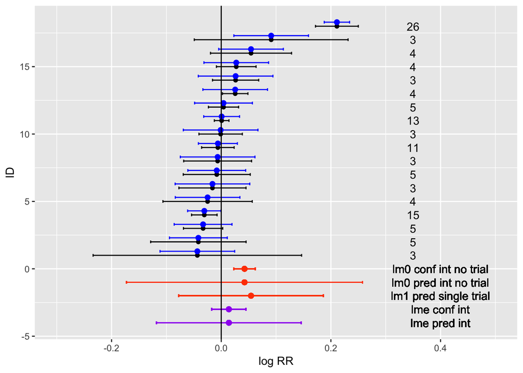

## Bayesian model using MCMCglmm

In this first example we are using the pacakge ‘MCMCglmm’. We do not provide priors and these are created internally, but they are uninformative. In the following chapter there is an example of doing Bayesian meta-analysis using JAGS.

```r
soy.mc <- MCMCglmm(lrr ~ 1, random = ~ Trial_ID, pr = TRUE,
                  data = soy.o, verbose = FALSE)
soy.mc.ci <- as.vector(summary(soy.mc)$solutions)[1:3]
## With non informative priors the results are almost identical
## to the lme solution
round(exp(rbind(pp.lme, soy.mc.ci)),3)
```

```
##           (Intercept) 2.5 % 97.5 %
## pp.lme          1.014 0.983  1.046
## soy.mc.ci       1.015 0.986  1.048
```

```r
## Calculating a predictive interval using MCMCglmm
## The trick here is that we computed predictions for each
## individual trial and then pick the trial which is closer
## to the mean
ndat <- data.frame(lrr = soy.mc.ci[1], Trial_ID = unique(soy.o$Trial_ID))
soy.mc.pi <- predict(soy.mc, newdata = ndat, interval = "prediction")
soy.mc.pi <- data.frame(ndat,soy.mc.pi)
pmt2 <- with(soy.mc.pi, which.min(abs(lrr[1] - fit)))
soy.mc.pi.st <- soy.mc.pi[pmt2,]
round(exp(soy.mc.pi.st[-2]),3)
```

|  | lrr | fit | lwr | upr |
| --- | --- | --- | --- | --- |
| 16 | 1.015 | 1.015 | 0.858 | 1.196 |

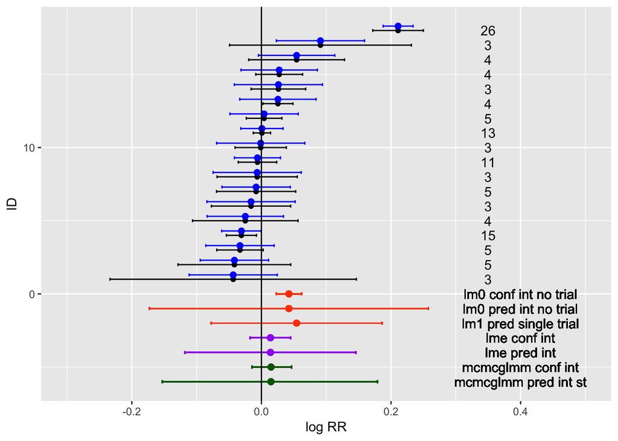

## Bayesian model using JAGS

```r
soyd <- list(lrr = soy.o$lrr, trial = soy.o$Trial_ID,
           t.n = length(unique(soy.o$Trial_ID)),
           n = nrow(soy.o))
init <- list(mu = 0, tau = 0.01, tau.trial = 0.01)
modelstring="
  model {
    # Single intercept model likelihood
    for (i in 1:n) {
      lrr[i]~dnorm(mu + b[trial[i]],tau)
    }

    # trial effect
    for(j in 1:t.n){
      b[j] ~ dnorm(0, tau.trial)
    }

    # priors
    mu ~ dnorm(0,0.00001) # intercept prior
    tau ~ dgamma(0.0001,0.0001) ## tau is the residual precision
    sigma <- 1.0/sqrt(tau)
    tau.trial ~ dgamma(0.0001, 0.0001)
    sigma.trial <- 1.0/sqrt(tau.trial)
    # generate predictions
    beff ~ dnorm(0, tau.trial)
    pred <- mu + beff
  }
"
mdl=jags.model(textConnection(modelstring), data=soyd, inits=init,
               n.chains = 2)
update(mdl,n.iter = 5000, n.burnin=2000)
output=coda.samples(model=mdl,
                    variable.names=c("mu","pred","sigma","sigma.trial"),
                    n.iter=10000, thin=10)
print(summary(output))
```

```
##
## Iterations = 5010:15000
## Thinning interval = 10
## Number of chains = 2
## Sample size per chain = 1000
##
## 1. Empirical mean and standard deviation for each variable,
##    plus standard error of the mean:
##
##                Mean       SD  Naive SE Time-series SE
## mu          0.01417 0.015925 3.561e-04      4.844e-04
## pred        0.01698 0.065620 1.467e-03      1.454e-03
## sigma       0.05941 0.004185 9.358e-05      9.348e-05
## sigma.trial 0.06306 0.012258 2.741e-04      2.763e-04
##
## 2. Quantiles for each variable:
##
##                 2.5%       25%     50%     75%   97.5%
## mu          -0.01621  0.003491 0.01443 0.02478 0.04502
## pred        -0.11270 -0.024363 0.01515 0.05796 0.14545
## sigma        0.05211  0.056455 0.05911 0.06193 0.06833
## sigma.trial  0.04370  0.054524 0.06168 0.07018 0.09196
```

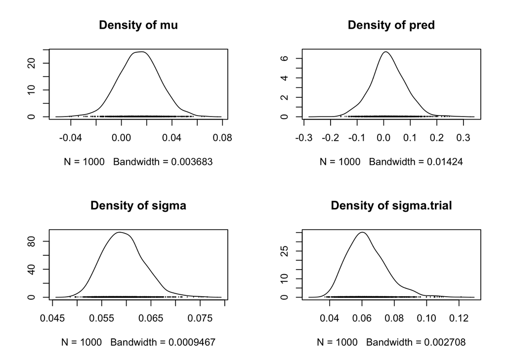

```r
plot(output, trace = FALSE)
```

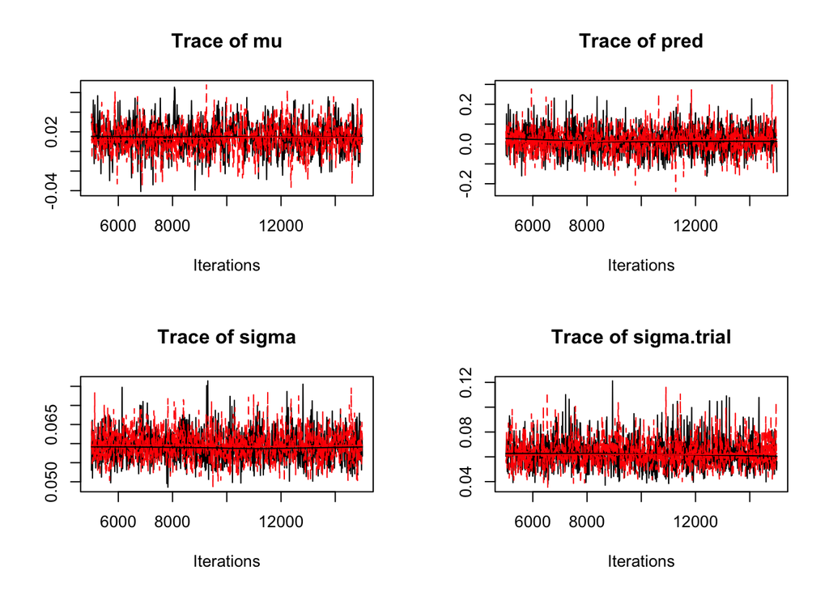

```r
plot(output, density = FALSE)
```

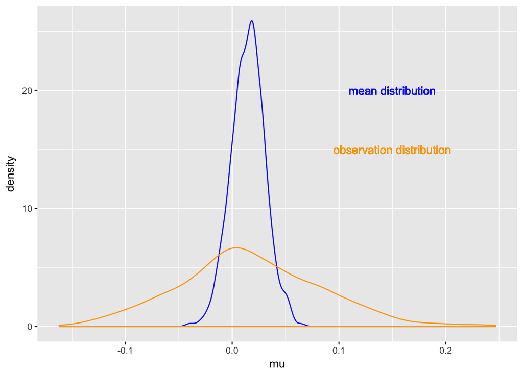

[figure not shown]

```r
mcmc.chains <- as.data.frame(unclass(output[[1]]))

## Process data for graph
## Mean and intervals for mu
soy.mcj.m <- quantile(mcmc.chains$mu, c(0.025,0.5,0.975))
soy.mcj.p <- quantile(mcmc.chains$pred, c(0.025,0.5,0.975))

ggplot(data = mcmc.chains) +
  geom_density(aes(x = mu, y = ..density..), color = "blue")+
  geom_density(aes(x = pred, y = ..density..), color = "orange") +
  geom_text(aes(x = 0.15, y = 20), label = "mean distribution",
            color = "blue") +
  geom_text(aes(x = 0.15, y = 15), label = "observation distribution",
            color = "orange")
```

## Tutorial about the use of the metafor package

I could include here examples using the metafor package as a way for me to learn how to do this and to see what the differences are with the methods I have been using.

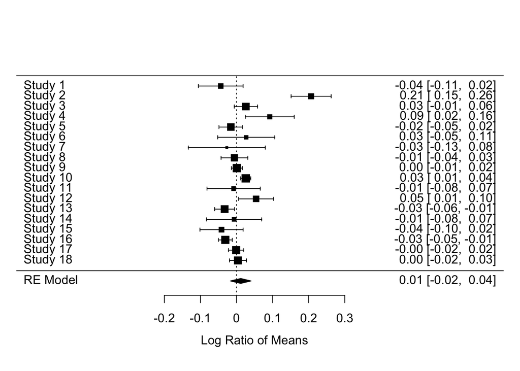

```r
soy.m1i <- aggregate(TRT1_Yld ~ Trial_ID, data = soy.o, FUN = mean)[,2]
soy.m2i <- aggregate(TRT2_Yld ~ Trial_ID, data = soy.o, FUN = mean)[,2]
soy.sd1i <- aggregate(TRT1_Yld ~ Trial_ID, data = soy.o, FUN = sd)[,2]
soy.sd2i <- aggregate(TRT2_Yld ~ Trial_ID, data = soy.o, FUN = sd)[,2]
soy.n1i <- aggregate(TRT1_Yld ~ Trial_ID, data = soy.o, FUN = length)[,2]
soy.n2i <- aggregate(TRT2_Yld ~ Trial_ID, data = soy.o, FUN = length)[,2]

rr.escl <- escalc("ROM", m1i = soy.m1i, m2i = soy.m2i,
                         sd1i = soy.sd1i, sd2i = soy.sd2i,
                         n1i = soy.n1i, n2i = soy.n2i)
soy.rma <- rma(yi, vi, data = rr.escl, test = "knha")
forest(soy.rma)
```

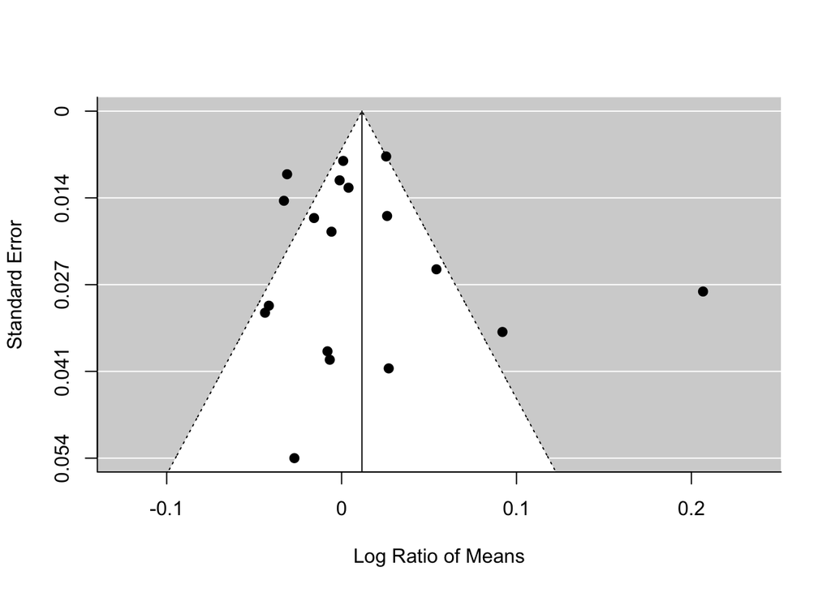

```r
funnel(soy.rma)
```